# Processing scRNA-Seq Data with Seurat

## Introduction

This is a brief introduction to working with single-cell RNA sequencing (scRNA-seq) data in Seurat. The primary dataset used here contains hematopoietic populations from the bone marrow of healthy and AML patients ([van Galen et al.](https://doi.org/10.1016/j.cell.2019.01.031)). The data is available in GEO under accession GSE116256.

## Import data

Load Seurat and tidyverse packages.

```r
library(tidyverse)
library(Seurat)
library(ggsci)
```

Import the digital expression matrix for sample AML329-D0. The `readr::read_tsv()` function can download data from a remote source.

```r
AML329_dem_tbl = read_tsv("https://ftp.ncbi.nlm.nih.gov/geo/samples/GSM3587nnn/GSM3587940/suppl/GSM3587940_AML329-D0.dem.txt.gz", show_col_types = FALSE)
dim(AML329_dem_tbl)
```

```
[1] 27899   526
```

```r
AML329_dem_tbl[1:5, 1:3]
```

| Gene | AML329-D0_AAACAAACCTCN | AML329-D0_AAACTAAGCTGC |
| --- | --- | --- |
| A1BG | 0 | 0 |
| A1BG-AS1 | 0 | 0 |
| A1CF | 0 | 0 |
| A2M | 0 | 0 |
| A2M-AS1 | 0 | 0 |

Import the annotations for sample AML329-D0.

```r
AML329_annot_tbl = read_tsv("https://ftp.ncbi.nlm.nih.gov/geo/samples/GSM3587nnn/GSM3587941/suppl/GSM3587941_AML329-D0.anno.txt.gz", show_col_types = FALSE)
dim(AML329_annot_tbl)
```

```
[1] 525  28
```

```r
head(AML329_annot_tbl)
```

| Cell | NumberOfReads | AlignedToGenome | AlignedToTranscriptome | TranscriptomeUMIs | NumberOfGenes | CyclingScore | CyclingBinary | MutTranscripts | WtTranscripts | PredictionRF2 | PredictionRefined | CellType | Score_HSC | Score_Prog | Score_GMP | Score_ProMono | Score_Mono | Score_cDC | Score_pDC | Score_earlyEry | Score_lateEry | Score_ProB | Score_B | Score_Plasma | Score_T | Score_CTL | Score_NK |
| --- | --- | --- | --- | --- | --- | --- | --- | --- | --- | --- | --- | --- | --- | --- | --- | --- | --- | --- | --- | --- | --- | --- | --- | --- | --- | --- | --- |
| AML329-D0_AAACAAACCTCN | 94720 | 66021 | 46639 | 4039 | 1362 | -0.035 | no | NA | NA | normal | normal | GMP | 0.086 | 0.130 | 0.367 | 0.073 | 0.022 | 0.029 | 0.020 | 0.056 | 0.017 | 0.035 | 0.020 | 0.005 | 0.023 | 0.079 | 0.038 |
| AML329-D0_AAACTAAGCTGC | 166387 | 117691 | 87558 | 5770 | 1717 | -0.609 | no | NPM1.W288fs/913 /// NPM1.W288fs/393 | NPM1.wt/7898 /// NPM1.wt/3292 | malignant | malignant | GMP-like | 0.118 | 0.190 | 0.373 | 0.080 | 0.017 | 0.033 | 0.016 | 0.064 | 0.021 | 0.017 | 0.019 | 0.006 | 0.026 | 0.012 | 0.008 |
| AML329-D0_AAACTTACACAN | 73022 | 53759 | 39957 | 3051 | 1122 | -0.626 | no | NA | NPM1.wt/582 /// NPM1.wt/67 /// NPM1.wt/330 | malignant | malignant | Prog-like | 0.218 | 0.248 | 0.058 | 0.010 | 0.018 | 0.029 | 0.059 | 0.126 | 0.046 | 0.051 | 0.047 | 0.014 | 0.037 | 0.020 | 0.019 |
| AML329-D0_AAAGTTACAAAT | 42430 | 31000 | 22831 | 1580 | 619 | -0.399 | no | NA | NA | normal | normal | T | 0.029 | 0.026 | 0.012 | 0.005 | 0.006 | 0.015 | 0.023 | 0.027 | 0.010 | 0.029 | 0.053 | 0.011 | 0.554 | 0.136 | 0.064 |
| AML329-D0_AAGAGGGCGATC | 56136 | 42217 | 19703 | 1590 | 759 | -0.449 | no | NA | NPM1.wt/10137 /// NPM1.wt/3056 | normal | normal | Mono | 0.058 | 0.078 | 0.050 | 0.111 | 0.271 | 0.141 | 0.031 | 0.032 | 0.012 | 0.023 | 0.044 | 0.017 | 0.048 | 0.046 | 0.038 |
| AML329-D0_AAGTTCTGGTGT | 28442 | 22069 | 11172 | 1036 | 522 | -0.320 | no | NA | NA | normal | normal | CTL | 0.026 | 0.019 | 0.014 | 0.013 | 0.009 | 0.007 | 0.016 | 0.023 | 0.016 | 0.024 | 0.071 | 0.017 | 0.214 | 0.301 | 0.230 |

## Clean up data

By default, `readr::read_tsv` will create a tibble (“data.frames that are lazy and surly”). The expression data should be a matrix with genes as rows and cells as columns.

```r
class(AML329_dem_tbl)
```

```
[1] "spec_tbl_df" "tbl_df"      "tbl"         "data.frame"
```

```r
AML329_dem_mat = AML329_dem_tbl %>% column_to_rownames("Gene") %>% as.matrix()
AML329_dem_mat[1:5, 1:3]
```

```
         AML329-D0_AAACAAACCTCN AML329-D0_AAACTAAGCTGC AML329-D0_AAACTTACACAN
A1BG                          0                      0                      1
A1BG-AS1                      0                      0                      0
A1CF                          0                      0                      0
A2M                           0                      0                      0
A2M-AS1                       0                      0                      0
```

```r
AML329_dem_mat %>% colSums() %>% summary()
```

```
   Min. 1st Qu.  Median    Mean 3rd Qu.    Max.
   1005    1500    2309    3444    4369   27174
```

The annotation data should be a data frame.

```r
AML329_anno_df = AML329_annot_tbl %>% column_to_rownames("Cell") %>% as.data.frame()
head(AML329_anno_df)
```

|  | NumberOfReads | AlignedToGenome | AlignedToTranscriptome | TranscriptomeUMIs | NumberOfGenes | CyclingScore | CyclingBinary | MutTranscripts | WtTranscripts | PredictionRF2 | PredictionRefined | CellType | Score_HSC | Score_Prog | Score_GMP | Score_ProMono | Score_Mono | Score_cDC | Score_pDC | Score_earlyEry | Score_lateEry | Score_ProB | Score_B | Score_Plasma | Score_T | Score_CTL | Score_NK |
| --- | --- | --- | --- | --- | --- | --- | --- | --- | --- | --- | --- | --- | --- | --- | --- | --- | --- | --- | --- | --- | --- | --- | --- | --- | --- | --- | --- |
| AML329-D0_AAACAAACCTCN | 94720 | 66021 | 46639 | 4039 | 1362 | -0.035 | no | NA | NA | normal | normal | GMP | 0.086 | 0.130 | 0.367 | 0.073 | 0.022 | 0.029 | 0.020 | 0.056 | 0.017 | 0.035 | 0.020 | 0.005 | 0.023 | 0.079 | 0.038 |
| AML329-D0_AAACTAAGCTGC | 166387 | 117691 | 87558 | 5770 | 1717 | -0.609 | no | NPM1.W288fs/913 /// NPM1.W288fs/393 | NPM1.wt/7898 /// NPM1.wt/3292 | malignant | malignant | GMP-like | 0.118 | 0.190 | 0.373 | 0.080 | 0.017 | 0.033 | 0.016 | 0.064 | 0.021 | 0.017 | 0.019 | 0.006 | 0.026 | 0.012 | 0.008 |
| AML329-D0_AAACTTACACAN | 73022 | 53759 | 39957 | 3051 | 1122 | -0.626 | no | NA | NPM1.wt/582 /// NPM1.wt/67 /// NPM1.wt/330 | malignant | malignant | Prog-like | 0.218 | 0.248 | 0.058 | 0.010 | 0.018 | 0.029 | 0.059 | 0.126 | 0.046 | 0.051 | 0.047 | 0.014 | 0.037 | 0.020 | 0.019 |
| AML329-D0_AAAGTTACAAAT | 42430 | 31000 | 22831 | 1580 | 619 | -0.399 | no | NA | NA | normal | normal | T | 0.029 | 0.026 | 0.012 | 0.005 | 0.006 | 0.015 | 0.023 | 0.027 | 0.010 | 0.029 | 0.053 | 0.011 | 0.554 | 0.136 | 0.064 |
| AML329-D0_AAGAGGGCGATC | 56136 | 42217 | 19703 | 1590 | 759 | -0.449 | no | NA | NPM1.wt/10137 /// NPM1.wt/3056 | normal | normal | Mono | 0.058 | 0.078 | 0.050 | 0.111 | 0.271 | 0.141 | 0.031 | 0.032 | 0.012 | 0.023 | 0.044 | 0.017 | 0.048 | 0.046 | 0.038 |
| AML329-D0_AAGTTCTGGTGT | 28442 | 22069 | 11172 | 1036 | 522 | -0.320 | no | NA | NA | normal | normal | CTL | 0.026 | 0.019 | 0.014 | 0.013 | 0.009 | 0.007 | 0.016 | 0.023 | 0.016 | 0.024 | 0.071 | 0.017 | 0.214 | 0.301 | 0.230 |

```r
summary(AML329_anno_df$TranscriptomeUMIs)
```

```
   Min. 1st Qu.  Median    Mean 3rd Qu.    Max.
   1005    1500    2309    3444    4369   27174
```

```r
summary(AML329_anno_df$NumberOfGenes)
```

```
   Min. 1st Qu.  Median    Mean 3rd Qu.    Max.
    501     648     893    1142    1468    4679
```

```r
table(AML329_anno_df$CellType, useNA = "ifany")
```

```
           B          cDC     cDC-like          CTL     earlyEry          GMP
          16           12           25            8            7           13
    GMP-like          HSC     HSC-like      lateEry         Mono    Mono-like
         134            2            9           45           33           11
          NK          pDC       Plasma         Prog    Prog-like      ProMono
          29            2            4           13           67            8
ProMono-like            T
           7           80
```

```r
table(AML329_anno_df$PredictionRefined, useNA = "ifany")
```

```
malignant    normal
      253       272
```

## Create the Seurat object

Initialize the Seurat object with the raw counts.

```r
AML329_so = CreateSeuratObject(counts = AML329_dem_mat, min.cells = 1, min.features = 1)
AML329_so
```

```
An object of class Seurat
15909 features across 525 samples within 1 assay
Active assay: RNA (15909 features, 0 variable features)
```

By default, all the data is stored in the `RNA` assay.

```r
AML329_so@assays
```

```
$RNA
Assay data with 15909 features for 525 cells
First 10 features:
 A1BG, A1BG-AS1, A2M, A2M-AS1, A2ML1, A2MP1, A4GALT, AAAS, AACS, AADAT
```

The `[[` operator can add columns to object metadata. We can add the percentage of reads that map to the mitochondrial genome.

```r
AML329_so[["pct_mito"]] = PercentageFeatureSet(AML329_so, pattern = "^MT-")
```

The metadata is stored in the `meta.data` slot.

```r
head(AML329_so@meta.data)
```

|  | orig.ident | nCount_RNA | nFeature_RNA | pct_mito |
| --- | --- | --- | --- | --- |
| AML329-D0_AAACAAACCTCN | AML329-D0 | 4039 | 1362 | 5.669720 |
| AML329-D0_AAACTAAGCTGC | AML329-D0 | 5770 | 1717 | 2.218371 |
| AML329-D0_AAACTTACACAN | AML329-D0 | 3051 | 1122 | 3.179285 |
| AML329-D0_AAAGTTACAAAT | AML329-D0 | 1580 | 619 | 1.392405 |
| AML329-D0_AAGAGGGCGATC | AML329-D0 | 1590 | 759 | 3.333333 |
| AML329-D0_AAGTTCTGGTGT | AML329-D0 | 1036 | 522 | 2.413127 |

We can add additional metadata using `AddMetaData()`.

```r
AML329_so = AddMetaData(AML329_so, metadata = AML329_anno_df)
head(AML329_so@meta.data)
```

|  | orig.ident | nCount_RNA | nFeature_RNA | pct_mito | NumberOfReads | AlignedToGenome | AlignedToTranscriptome | TranscriptomeUMIs | NumberOfGenes | CyclingScore | CyclingBinary | MutTranscripts | WtTranscripts | PredictionRF2 | PredictionRefined | CellType | Score_HSC | Score_Prog | Score_GMP | Score_ProMono | Score_Mono | Score_cDC | Score_pDC | Score_earlyEry | Score_lateEry | Score_ProB | Score_B | Score_Plasma | Score_T | … |
| --- | --- | --- | --- | --- | --- | --- | --- | --- | --- | --- | --- | --- | --- | --- | --- | --- | --- | --- | --- | --- | --- | --- | --- | --- | --- | --- | --- | --- | --- | --- |
| AML329-D0_AAACAAACCTCN | AML329-D0 | 4039 | 1362 | 5.669720 | 94720 | 66021 | 46639 | 4039 | 1362 | -0.035 | no | NA | NA | normal | normal | GMP | 0.086 | 0.130 | 0.367 | 0.073 | 0.022 | 0.029 | 0.020 | 0.056 | 0.017 | 0.035 | 0.020 | 0.005 | 0.023 | … |
| AML329-D0_AAACTAAGCTGC | AML329-D0 | 5770 | 1717 | 2.218371 | 166387 | 117691 | 87558 | 5770 | 1717 | -0.609 | no | NPM1.W288fs/913 /// NPM1.W288fs/393 | NPM1.wt/7898 /// NPM1.wt/3292 | malignant | malignant | GMP-like | 0.118 | 0.190 | 0.373 | 0.080 | 0.017 | 0.033 | 0.016 | 0.064 | 0.021 | 0.017 | 0.019 | 0.006 | 0.026 | … |
| AML329-D0_AAACTTACACAN | AML329-D0 | 3051 | 1122 | 3.179285 | 73022 | 53759 | 39957 | 3051 | 1122 | -0.626 | no | NA | NPM1.wt/582 /// NPM1.wt/67 /// NPM1.wt/330 | malignant | malignant | Prog-like | 0.218 | 0.248 | 0.058 | 0.010 | 0.018 | 0.029 | 0.059 | 0.126 | 0.046 | 0.051 | 0.047 | 0.014 | 0.037 | … |
| AML329-D0_AAAGTTACAAAT | AML329-D0 | 1580 | 619 | 1.392405 | 42430 | 31000 | 22831 | 1580 | 619 | -0.399 | no | NA | NA | normal | normal | T | 0.029 | 0.026 | 0.012 | 0.005 | 0.006 | 0.015 | 0.023 | 0.027 | 0.010 | 0.029 | 0.053 | 0.011 | 0.554 | … |
| AML329-D0_AAGAGGGCGATC | AML329-D0 | 1590 | 759 | 3.333333 | 56136 | 42217 | 19703 | 1590 | 759 | -0.449 | no | NA | NPM1.wt/10137 /// NPM1.wt/3056 | normal | normal | Mono | 0.058 | 0.078 | 0.050 | 0.111 | 0.271 | 0.141 | 0.031 | 0.032 | 0.012 | 0.023 | 0.044 | 0.017 | 0.048 | … |
| AML329-D0_AAGTTCTGGTGT | AML329-D0 | 1036 | 522 | 2.413127 | 28442 | 22069 | 11172 | 1036 | 522 | -0.320 | no | NA | NA | normal | normal | CTL | 0.026 | 0.019 | 0.014 | 0.013 | 0.009 | 0.007 | 0.016 | 0.023 | 0.016 | 0.024 | 0.071 | 0.017 | 0.214 | … |

These cells are already pre-filtered, but we can visualize QC metrics anyway.

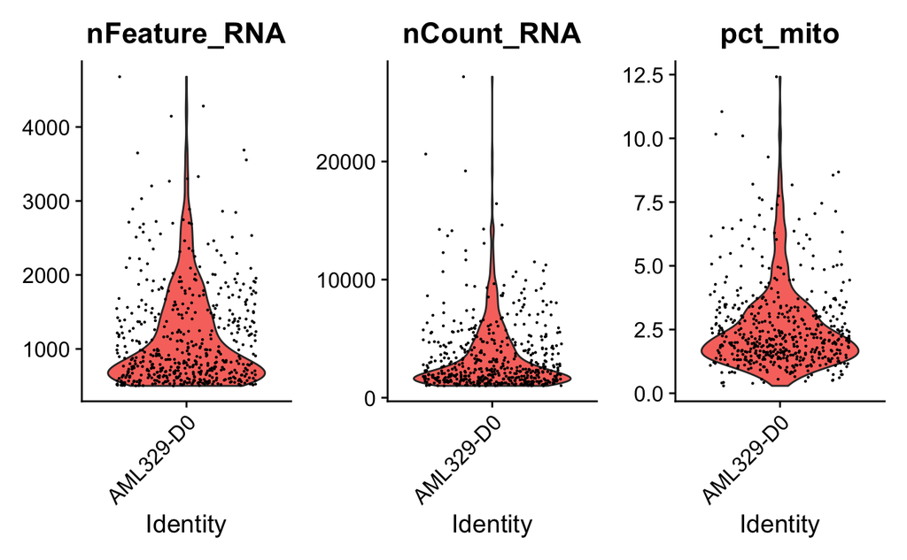

```r
VlnPlot(AML329_so, features = c("nFeature_RNA", "nCount_RNA", "pct_mito"), ncol = 3)
```

## Perform standard analysis (log-transformed)

The default global-scaling normalization method `LogNormalize` normalizes the feature expression measurements for each cell by the total expression, multiplies by a scale factor of 10,000, and log-transforms the result.

```r
AML329_so = NormalizeData(AML329_so, normalization.method = "LogNormalize")
```

The normalized values are stored in the `data` slot in the `RNA` assay.

```r
# AML329_so[["RNA"]]@data[1:5, 1:3]
AML329_so@assays$RNA@data[1:5, 1:3]
```

```
5 x 3 sparse Matrix of class "dgCMatrix"
         AML329-D0_AAACAAACCTCN AML329-D0_AAACTAAGCTGC AML329-D0_AAACTTACACAN
A1BG                          .                      .               1.453395
A1BG-AS1                      .                      .               .
A2M                           .                      .               .
A2M-AS1                       .                      .               .
A2ML1                         .                      .               .
```

Each cell now has 10,000 normalized counts.

```r
AML329_so@assays$RNA@data %>% expm1() %>% colSums() %>% summary()
```

```
   Min. 1st Qu.  Median    Mean 3rd Qu.    Max.
  10000   10000   10000   10000   10000   10000
```

```r
AML329_so = FindVariableFeatures(AML329_so, verbose = FALSE)
AML329_so = ScaleData(AML329_so, vars.to.regress = "pct_mito", verbose = FALSE)
AML329_so = RunPCA(AML329_so, verbose = FALSE)
# AML329_so = FindNeighbors(AML329_so)
# AML329_so = FindClusters(AML329_so, resolution = c(0.8, 1, 1.2))
AML329_so = RunUMAP(AML329_so, dims = 1:30, verbose = FALSE)
```

The Seurat object now includes additional information that was generated.

```r
AML329_so
```

```
An object of class Seurat
15909 features across 525 samples within 1 assay
Active assay: RNA (15909 features, 2000 variable features)
 2 dimensional reductions calculated: pca, umap
```

## Generate UMAPs

Check the metadata overlaid onto the generated UMAP.

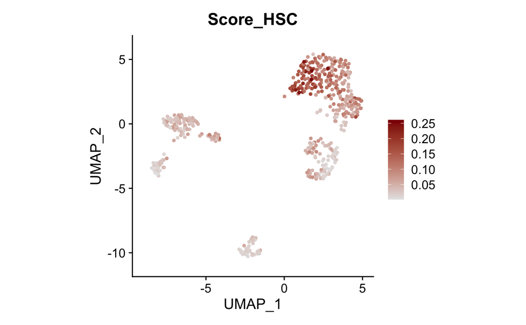

```r
FeaturePlot(AML329_so, reduction = "umap", features = "Score_HSC", cols = c("gray90", "red4")) +
  theme(aspect.ratio = 1)
```

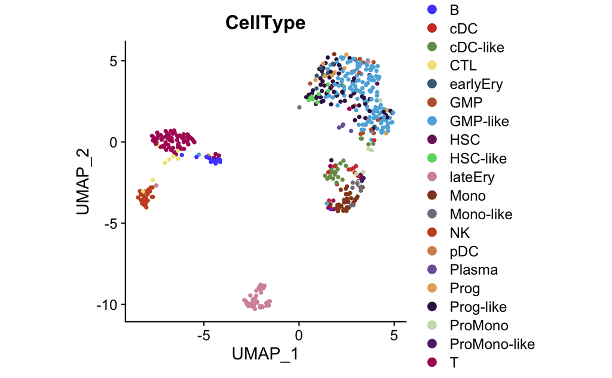

```r
DimPlot(AML329_so, reduction = "umap", group.by = "CellType", shuffle = TRUE) +
  theme(aspect.ratio = 1) +
  scale_color_igv()
```

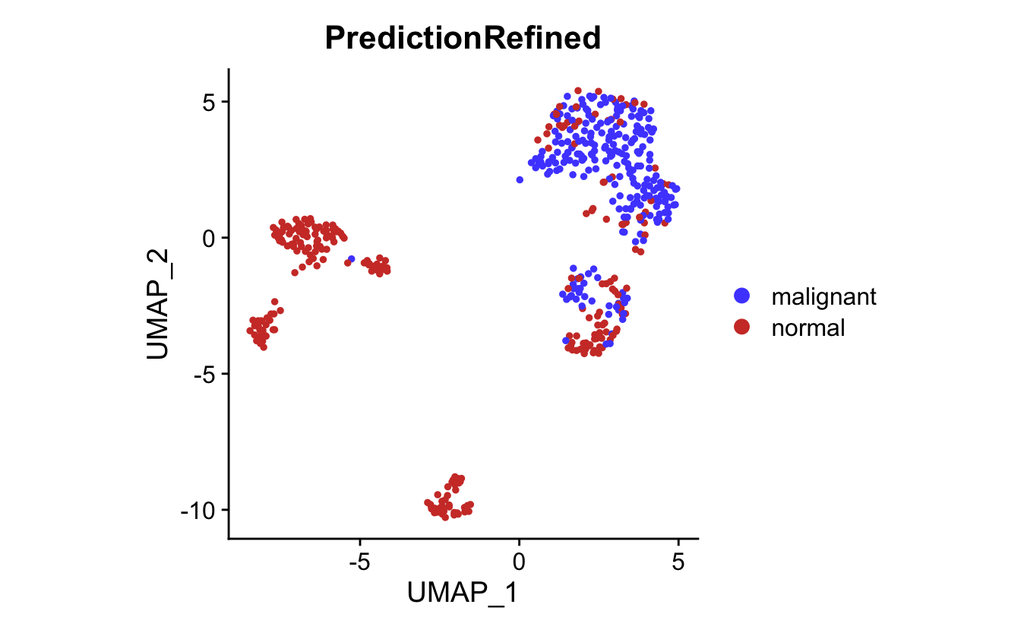

```r
DimPlot(AML329_so, reduction = "umap", group.by = "PredictionRefined", shuffle = TRUE) +
  theme(aspect.ratio = 1) +
  scale_color_igv()
```

## Perform sctransform-based analysis

Run sctransform.

```r
AML329_so = SCTransform(AML329_so, vars.to.regress = "pct_mito", verbose = FALSE)
```

The sctransform results are stored in the new `SCT` assay.

```r
AML329_so@assays
```

```
$RNA
Assay data with 15909 features for 525 cells
Top 10 variable features:
 HBB, HBD, HBA2, CA1, LYZ, S100A9, AHSP, SLC4A1, S100A8, HIST1H1B

$SCT
SCTAssay data with 11435 features for 525 cells, and 1 SCTModel(s)
Top 10 variable features:
 LYZ, HBB, HBD, S100A9, CA1, HBA2, S100A8, SLC4A1, AHSP, HBA1
```

```r
DefaultAssay(AML329_so)
```

```
[1] "SCT"
```

Perform dimensionality reduction.

```r
AML329_so = RunPCA(AML329_so, verbose = FALSE)
AML329_so = RunUMAP(AML329_so, dims = 1:30, verbose = FALSE)
```

## Generate sctransform-based UMAPs

Check the metadata overlaid onto the generated UMAP.

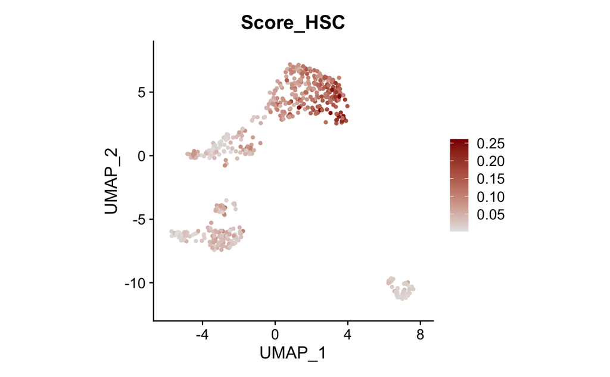

```r
FeaturePlot(AML329_so, reduction = "umap", features = "Score_HSC", cols = c("gray90", "red4")) +
  theme(aspect.ratio = 1)
```

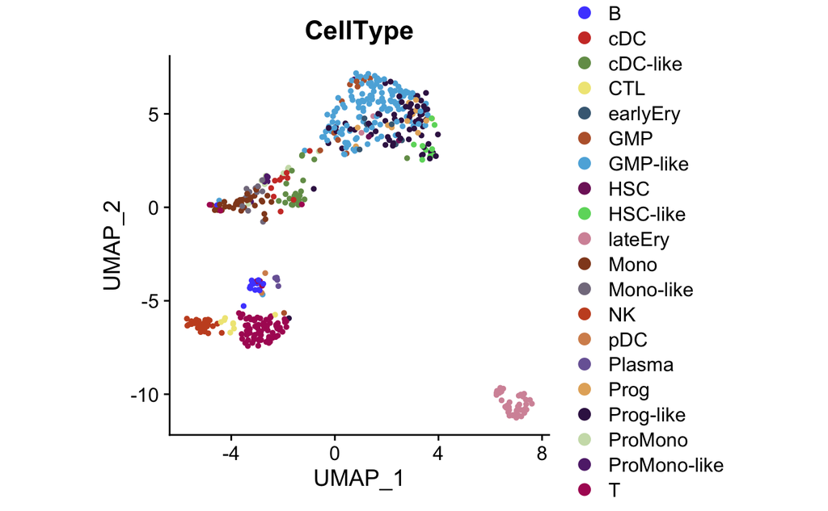

```r
DimPlot(AML329_so, reduction = "umap", group.by = "CellType", shuffle = TRUE) +
  theme(aspect.ratio = 1) +
  scale_color_igv()
```

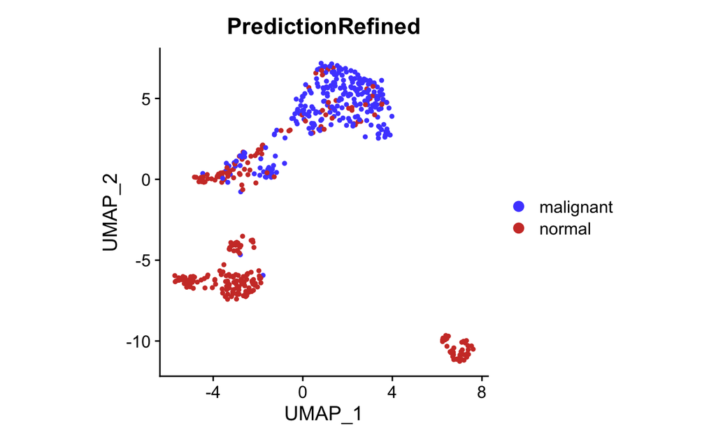

```r
DimPlot(AML329_so, reduction = "umap", group.by = "PredictionRefined", shuffle = TRUE) +
  theme(aspect.ratio = 1) +
  scale_color_igv()
```